[figure not shown]

[figure not shown]

[figure not shown]

[figure not shown]

# Factsheet toestand en ecologische sleutelfactoren (DIPS)

## Hoofdlijnen

### Beschrijving van het gebied en watersysteem op hoofdlijnen

Het Loenderveen oost (NL11_5_3) heeft watertype Matig grote ondiepe laagveenplassen (M27) en bestaat uit de deelgebieden: 3320-EAG-4 (Loenderveen, Loenderveensche Plas).

## Ligging en beeld

### Ligging waterlichaam

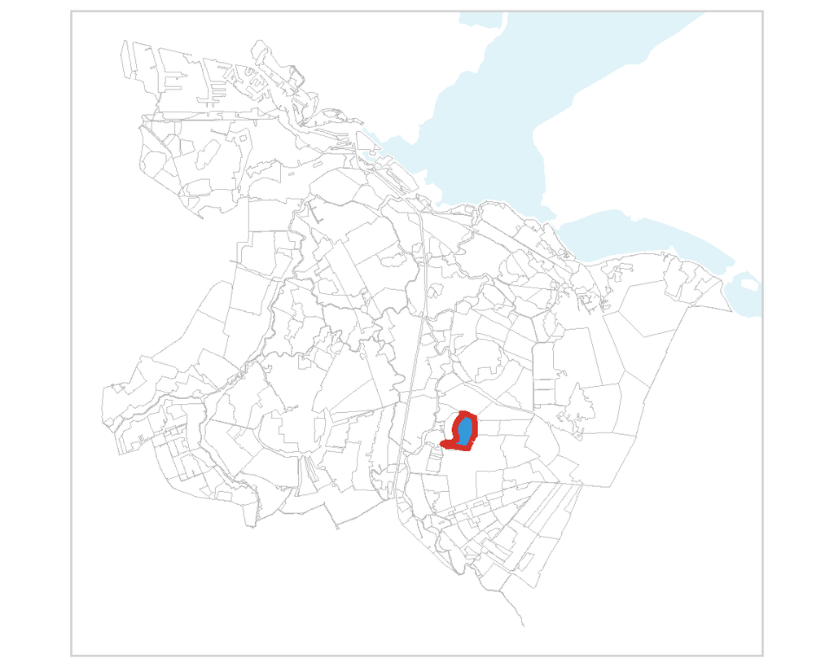

### Ligging deelgebieden

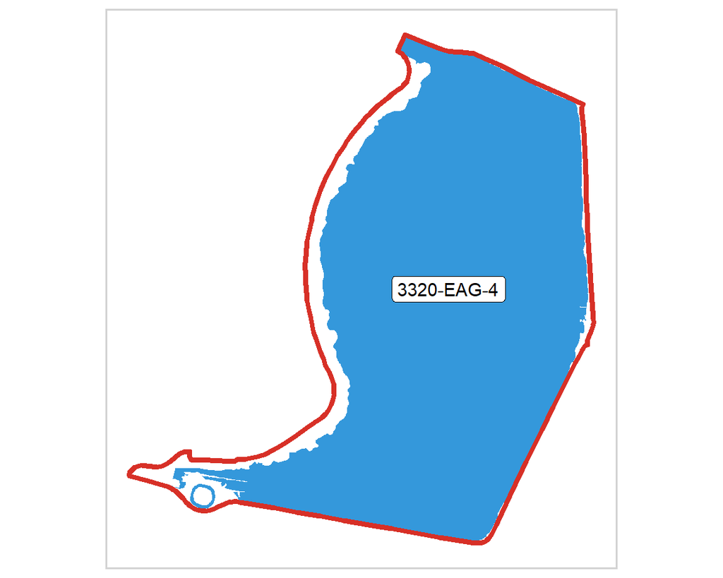

## Toestand

### Ecologische analyse op hoofdlijnen

**De doelen**

**De huidige toestand vergeleken met de doelen –**matig

**Oorzaken op hoofdlijnen**

Een mogelijke bedreiging voor de goede ecologische toestand is de rode Amerikaanse rivierkreeft die in het Naardermeer voorkomt.

**Maatregelen op hoofdlijnen**

### Toestand

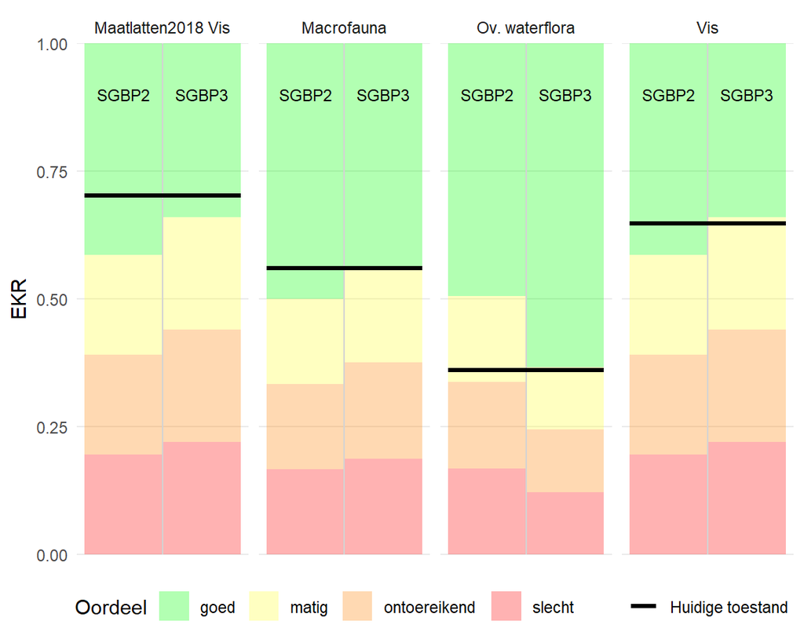

Huidige toestand vergeleken met doelen.De achtergrondkleuren in het figuur staan voor de klasseindeling van het huidige doel in de linkerbalk (SGBP2) en het technisch aangepaste CONCEPTdoel voor SGBP3 rechts. Wanneer de zwarte streep over de groene achtergrondkleur (GEP) valt is het doel gehaald.

## Bron

Deze factsheet is gebaseerd op de KRW toetsing aan (maatlatten 2018) uit 2019, begrenzing waterlichamen 2015-2021, hydrobiologische data 2006-2018 en conceptmaatregelen en doelen voor SGBP3 en Analyse Wi+Bo voor Defosfateren Bethuneoverschot, .